# Datos bivariados

Felipe González

En la clase anterior discutimos un algoritmo loess para suavizar, sin embargo, la versión que estudiamos no es resistente. En esta sección describiremos una manera de hacerlo resistente.

### Loess robusto

La técnica de loess robusto es iterativa (como muchos otros métodos exploratorios). Comenzamos definiendo la función *bicuadrado*:

$\begin{equation} B(u)=\begin{cases} (1-|u|^2)^2, & \text{para $|u| < 1$}.\\ 0, & \text{en otro caso}. \end{cases} \end{equation}$

y definimos $s$ como la mediana de los valores absolutos de los residuales $|\epsilon_i|$. A $s$ se le conoce como *desviación mediana absoluta*, y es una medida de la dispersión de los residuales.

Entonces, el ajuste loess $(\alpha, \lambda)$ resistente con el bicuadrado consiste en:

1. Ajustar con los parámetros una curva loess (como en el caso de loess no robusto).
2. Calcular los residuales $\epsilon_i$ y su desviación mediana absoluta $s$.
3. Caluclar los pesos $r_i$ para la observación $(x_i,y_i)$ como:

$r_i = B\bigg(\frac{\epsilon_i}{6s}\bigg)$

4. Reajustamos la curva loess con nuevos pesos dados por $r_iw_i(x)$ donde $w_i(x)$ son los pesos usuales.
5. Recaluclamos los residuales e iteramos hasta que la curva loess con nuevos pesos dados por $r_iw_i(x)$ no cambie.

#### Ejemplo: múltiples atípicos y loess

Veremos como suavizar estos datos y una posible manera de limpiarlos.

```r
library(dplyr) # manipulación de datos
library(gridExtra) # ordenar salida de gráficas
library(ftnonpar) # este paquete incluye los datos que nos interesan

data(balloon)
balloon_df <- data_frame(x = 1:length(balloon), y = balloon)
head(balloon_df)
```

```
Source: local data frame [6 x 2]

  x    y
1 1 0.76
2 2 0.76
3 3 0.76
4 4 0.76
5 5 0.76
6 6 0.76
```

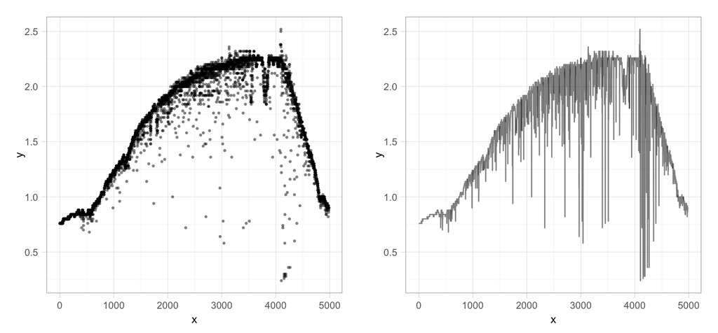

```r
balloon_pts <- ggplot(balloon_df, aes(x = x, y = y)) +
  geom_point(alpha = 0.5, size = 1.2)
balloon_line <- ggplot(balloon_df, aes(x = x, y = y)) +
  geom_line(alpha = 0.5)

grid.arrange(balloon_pts, balloon_line, ncol = 2)
```

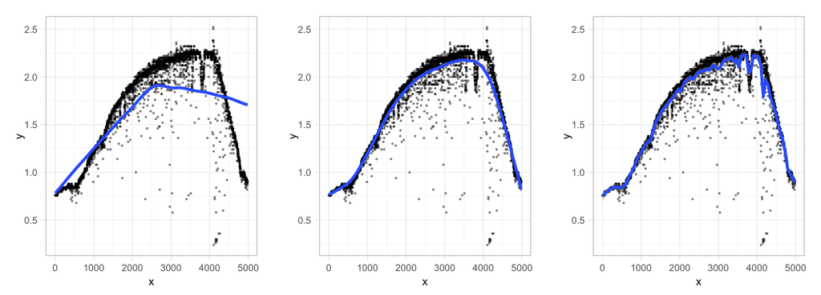

```r
loess_1 <- ggplot(balloon_df, aes(x = x, y = y)) +
  geom_point(alpha = 0.5, size = 1) +
  geom_smooth(method = "loess", span = 1, degree = 1, size = 1.2)

loess_2 <- ggplot(balloon_df, aes(x = x, y = y)) +
  geom_point(alpha = 0.5, size = 1) +
  geom_smooth(method = "loess", span = 0.2, degree = 1, size = 1.2)

loess_3 <- ggplot(balloon_df, aes(x = x, y = y)) +
  geom_point(alpha = 0.5, size = 1) +
  geom_smooth(method = "loess", span = 0.02, degree = 1, size = 1.2)

grid.arrange(loess_1, loess_2, loess_3, ncol = 3)
```

Ningún suavizamiento da un ajuste satisfactorio (si viéramos la gráfica de dependencia de residuales). Por su parte el loess robuste se ve como sigue:

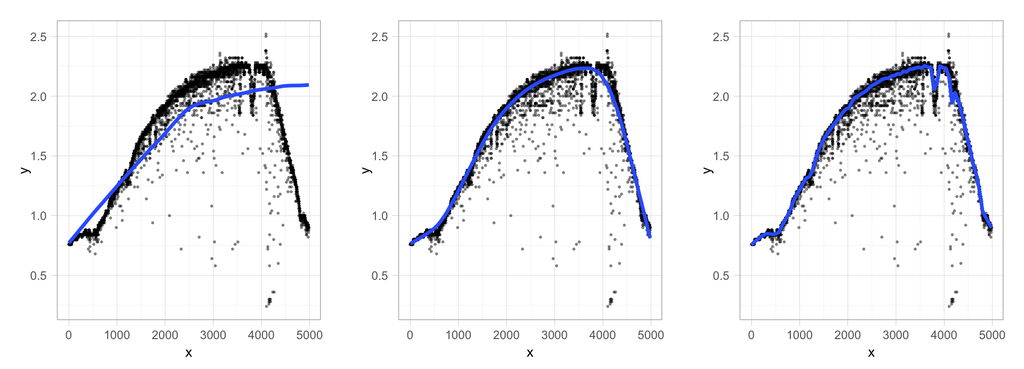

```r
loess_robusto_1 <- ggplot(balloon_df, aes(x = x, y = y)) +
  geom_point(alpha = 0.5, size = 1) +
  geom_smooth(family = "symmetric", method = "loess", span = 1, degree = 1,
    size = 1.2)

loess_robusto_2 <- ggplot(balloon_df, aes(x = x, y = y)) +
  geom_point(alpha = 0.5, size = 1) +
  geom_smooth(family = "symmetric", method = "loess", span = 0.2, degree = 1,
    size = 1.2)

loess_robusto_3 <- ggplot(balloon_df, aes(x = x, y = y)) +
  geom_point(alpha = 0.5, size = 1) +
  geom_smooth(family = "symmetric", method = "loess", span = 0.02, degree = 1,
    size = 1.2)

grid.arrange(loess_robusto_1, loess_robusto_2, loess_robusto_3, ncol = 3)
```

Ahora podemos marcar datos atípicos potenciales con una regla simple:

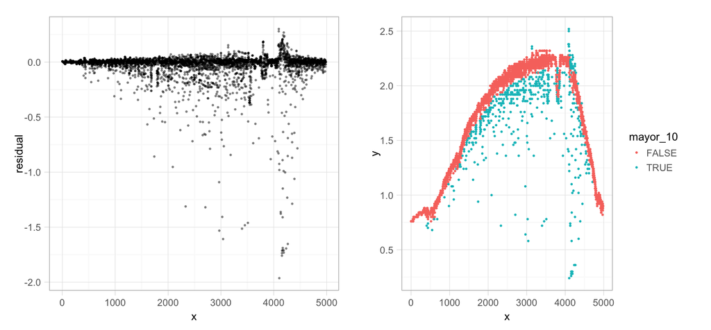

```r
ajuste_loess_robusto <- loess(y ~ x, data = balloon_df, family = "symmetric",
  span = 0.03, degree = 2)

balloon_df$residual <- ajuste_loess_robusto$residual

resid <- ggplot(balloon_df, aes(x, residual)) +
  geom_point(size = 1, alpha = 0.5)

balloon_df$mayor_10 <- ifelse(abs(balloon_df$residual) < 0.1, FALSE, TRUE)

balloon_resid <- ggplot(balloon_df, aes(x = x, y = y, color = mayor_10)) +
  geom_point(size = 1)

grid.arrange(resid, balloon_resid, ncol = 2)
```

### Residuales

El estudio de residuales puede hacerse de manera más detallada, observación por observación, especialmente cuando sospechamos que la variación alrededor del modelo que hemos propuesto se puede explicar con otros factores.

Como ejemplo veamos la relación entre consumo promedio diario de kilocalorías (kcal/persona/día) y proteína (gr/persona/día) en varios países, los datos corresponden a los años 2000-2002 y provienen de la [FAO](http://www.fao.org/fileadmin/templates/ess/documents/food_security_statistics/FoodConsumptionNutrients_en.xls)

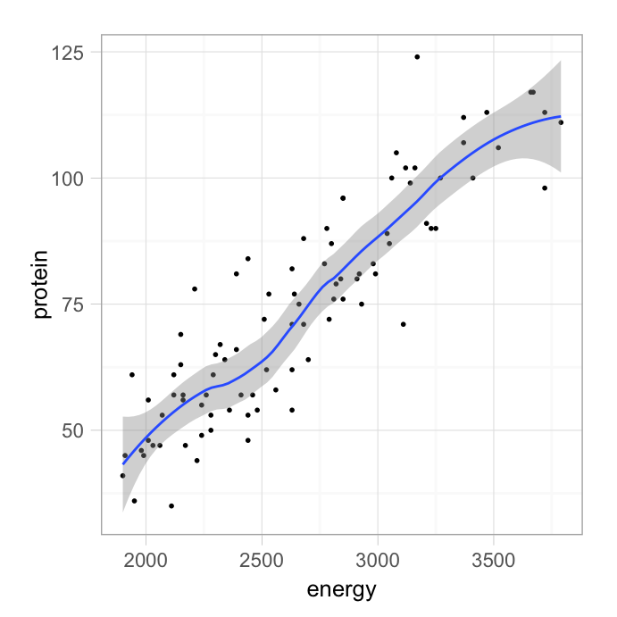

```r
library(readr)
dietas <- read_csv("datos/food_nutrients.csv")
set.seed(5339082)
dietas <- sample_n(dietas, 90)
ggplot(dietas, aes(x = energy, y = protein)) +
  geom_point(size = 1) +
  geom_smooth(method = "loess", family = "symmetric", span = 0.5)
```

Podemos agregar etiquetas para interpretar más facilmente.

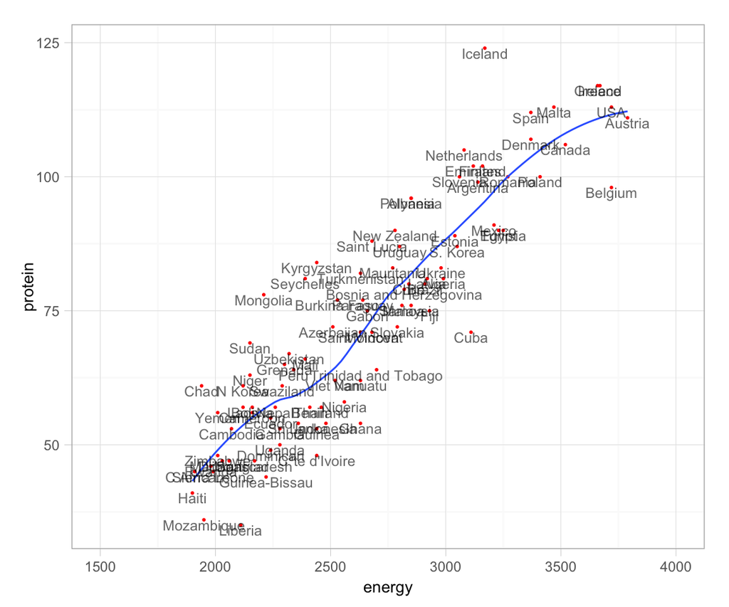

```r
ggplot(dietas, aes(x = energy, y = protein, label = country)) +
  geom_point(size = 1, color = "red") +
  geom_smooth(method = "loess", family = "symmetric", span = 0.5, se = FALSE) +
  geom_text(alpha = 0.6, size = 3, vjust = 1) +
  xlim(c(1500, 4000))
```

La relación energía y proteína es clara, y es la que esperaríamos (países donde se consume más en promedio se consumen más proteínas en promedio). En este caso es más interesante observar los países que se apartan del patrón general, es decir, la observación en los residuales de los países. Por ejemplo, en Islandia tiene un consumo de proteína muy alto para su consumo de energía. Su posición se opone a la de Bélgica, donde su consumo de proteína es relativamente bajo para su consumo calórico total.

Es posible mejorar esta gráfica cuidando más la posición de las etiquetas (usando el paquete *maptools* que hace recocido simulado para para optimizar la posición de las etiquetas).

```r
library(maptools)

etiquetar <- function(df, x, y, etiq = "etiq", size = 3.5){
  df <- as.data.frame(df)
  plot(df[, x], df[, y])
  orden <- pointLabel(df[, x], df[, y], df[, etiq], doPlot = TRUE,
    cex = 0.5 * size, xpd = TRUE)
  dev.off()
  df$a <- orden$x
  df$b <- orden$y
  df
}
set.seed(720528)
dietas_etiq <- etiquetar(dietas, "energy", "protein", etiq = "country",
  size = 1)
```

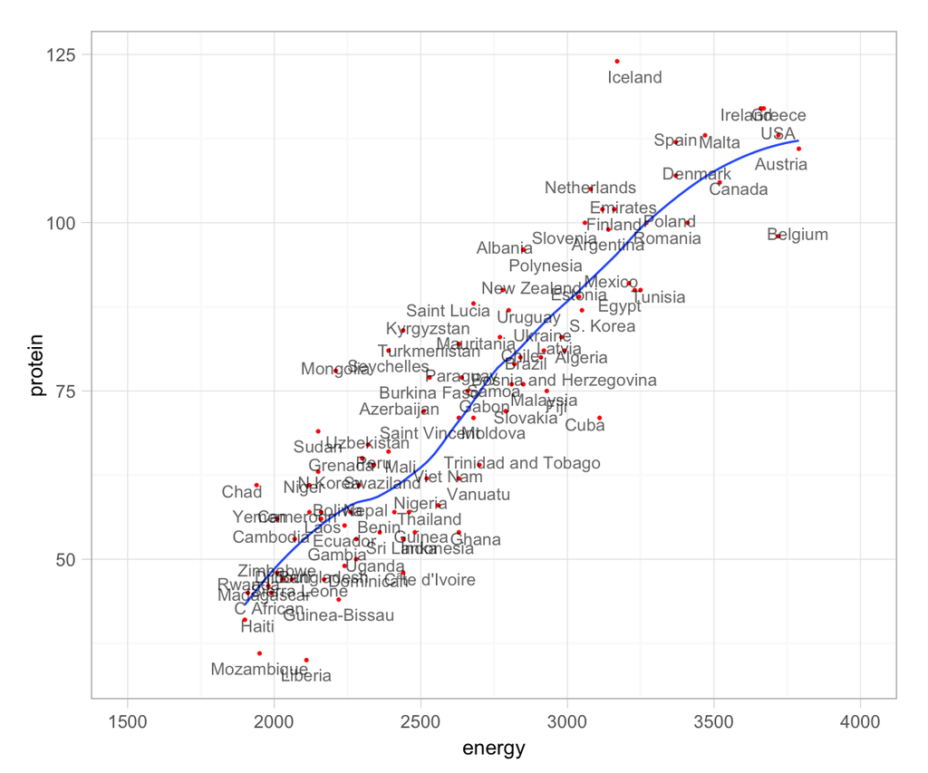

```r
ggplot(dietas_etiq, aes(x = energy, y = protein)) +
  geom_point(size = 1, color = "red") +
  geom_smooth(method = "loess", family = "symmetric", span = 0.5, se = FALSE) +
  geom_text(aes(x = a, y = b, label = country), alpha = 0.6, size = 2.8,
    vjust = 1) +
  xlim(c(1500, 4000))
```

Ahora podemos analizar los residuales, verificamos dependencia y dispersión homogénea.

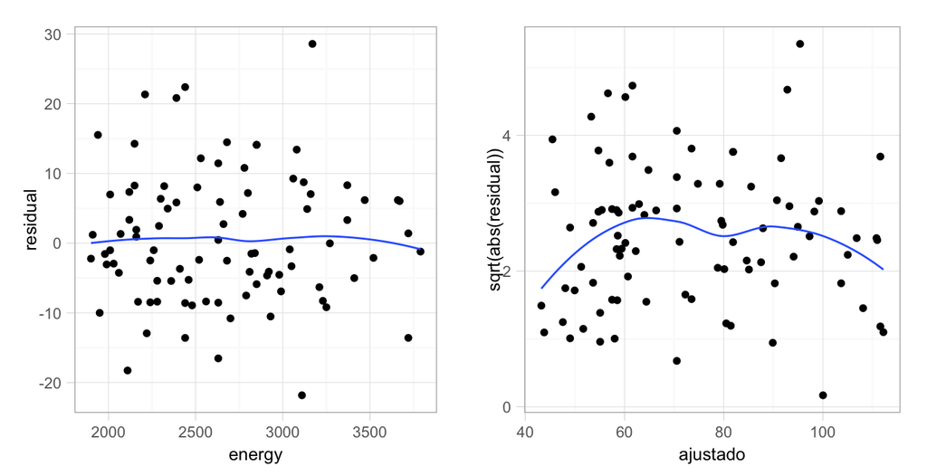

```r
ajuste_loess <- loess(protein ~ energy, dietas, family = "symmetric", span = 0.5)
dietas$residual <- ajuste_loess$residual
dietas$ajustado <- ajuste_loess$fitted

resid <- ggplot(dietas, aes(x = energy, y = residual)) +
  geom_point() +
  geom_smooth(se = FALSE)

resid_sqrt <- ggplot(dietas, aes(x = ajustado, y = sqrt(abs(residual)))) +
  geom_point() +
  geom_smooth(se = FALSE)

grid.arrange(resid, resid_sqrt, ncol = 2)
```

Finalmente , investigamos normalidad de los residuales:

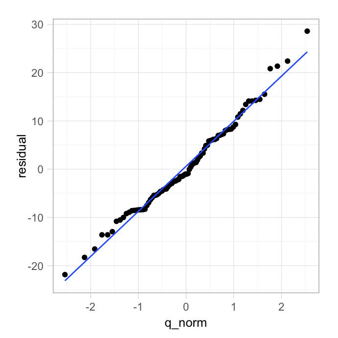

```r
dietas_norm <- arrange(dietas, residual)
dietas_norm$valor_f <- (1:nrow(dietas) - 0.5) / nrow(dietas)
dietas_norm$q_norm <- qnorm(dietas_norm$valor_f)
ggplot(dietas_norm, aes(x = q_norm, y = residual)) +
  geom_point() +
  geom_smooth(method = "lm", se = FALSE)
```

Es razonable usar la distribución normal para describir estos datos, aún cuando los países que consumen mucha proteína relativa a su consumo calórico tienden a alejarse un poco más de lo que sugeriría una distribución normal. Son Islandia, Kirgistán, Mongolia y Saychelles.

Nuestro resumen final es:

El consumo mediano de kcal a lo largo de los países es de 2600 kcal y el consumo mediano de proteinas es de unos 70 gr.  
El consumo de proteinas está relacionaa con el consumo energético total mediante la curva mostrada, que implica que aproximadamente aumenta 25gr de proteína cuando el consumo energético aumenta 500 kcal. Los países que menos consumen se ubican alrededor de 2000 kcal y unos 50 gr de proteínas, mientras que los que más consumen están alrededor de 3750 kcal y más de 110 gr de proteína. La variación de proteína sobre la curva es aproximadamente normal con desviación estándar de 9.4 gramos. Esto quiere decir que la mayoría del consumo de proteina en los países (95%) esta a no más de 19 gr de la curva.